# Data management and transfer

Week 11 – Lecture A

Author

Affiliations

Jelmer Poelstra

[CFAES Bioinformatics Core, Ohio State University](https://go.osu.edu/bioinformatics-core)

[Dept. of Plant Pathology, Ohio State University](https://plantpath.osu.edu)

Presented on

November 2, 2026

Page last modified

October 31, 2026

## 1 Introduction

### 1.1 Learning goals

- How you can manage your data and share it after publication
- How to organize sample metadata in spreadsheets
- Why you should prefer relative paths over absolute paths
- How to transfer files between OSC and other computers like your own
- How to download files at the command line
- How to compress and decompress files

### 1.2 Getting ready

   ```bash
   mkdir -p week11/sandbox
   cd week11
   ```

## 2 Relative paths and data management

In class, we’ll go through why you should prefer relative paths, and how to manage and share your data, using the slides below (**open them in a separate tab** for a full-screen view).

[interactive chart not shown]

## 3 File transfer to and from OSC

### 3.1 Overview of transfer options

In week 2, you learned that you can upload and download files from OSC in the OnDemand Files menu. However, that method is only suitable for relatively small transfers. Here is a table with methods to transfer files between your computer and OSC:

| Method | Transfer size | CLI or GUI | Ease of use | Flexibility/options |
| --- | --- | --- | --- | --- |
| **OnDemand Files menu** | smaller (<1GB) | GUI | Easy | Limited |
| **Remote transfer commands** (e.g. `scp`, `rsync`) | any | CLI | Moderate | Extensive |
| **SFTP** | any | Either | Moderate | Extensive |
| **Globus** | larger (>1GB) | GUI | Moderate | Extensive |

### 3.2 FileZilla: a GUI-based SFTP client

Here, we’ll go over what is probably overall the most convenient and versatile way to transfer files to and from OSC, since it works for transfers of any size, and is easy and quick: file transfer with a GUI-based SFTP client. There are several such programs, but I can recommend **FileZilla**[^1]. Let’s give that a try!

1. **Install FileZilla**
   - For *OSU-managed computers*: Open the “Software Center” (Windows) or “Ohio State Application Self Service” (Mac), search for “FileZilla”, and click the install button.
   - For *personal computers*: Go to the [FileZilla download page](https://filezilla-project.org/download.php?type=client) — it should automatically display a big green download button for your operating system: click on that, then install the program, and open it. On Windows, the installer may offer to install additional software: decline these offers.
2. **Connect to OSC**  
   Open FileZilla. To connect it to OSC, find the **Site Manager**: click `File` in the top menu bar and then `Site Manager`[^2]. In the Site Manager, click **New site**, name it e.g. `OSC`, and then enter/select the following:
   - *Protocol*: “SFTP - SSH File Transfer Protocol”
   - *Host*: `sftp.osc.edu` (leave the Port box empty)
   - *Logon Type*: Make sure “Normal” is selected
   - *User*: Type your OSC username
   - *Password*: Enter your OSC password
   - Click the “**Connect**” button at the bottom to connect to OSC

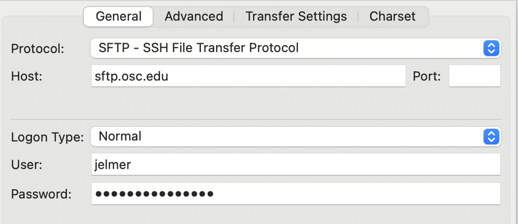

3. **The connection interface**  
   Once connected, your main screen is split with a local file explorer on the left, and a remote file explorer on the right:

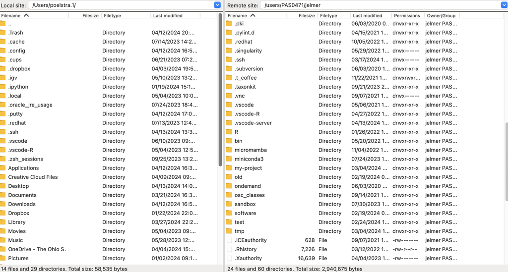

4. **Changing directories**  
   You can change directories in either file explorer. At OSC, your default location is your Home dir, but you can type a partial path in the top bar (e.g. `/fs/ess/PAS3493`) and then click your way to your personal dir.

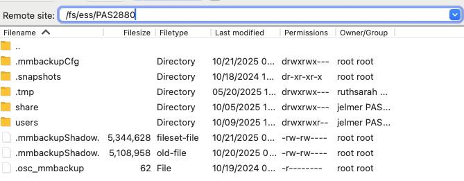

5. **Transferring files**  
   Transferring dirs and files in either direction is as simple as **dragging and dropping** them to the other side!

#### Exercise: File transfer with FileZilla

In FileZilla, go to `/fs/ess/PAS3493/people/<your-username>`. Then:

1. **Download** an HTML file to your computer, and open it in your browser: for example, a FastQC report from week 6 (in `week06/results/fastqc`).
2. **Upload** any small file from your computer to the same dir at OSC, and check that it’s there with `ls` in your VS Code terminal.

While this practice involved small files, you can use the same approach for much larger files that you can’t up/download via the OnDemand file browser, such as your raw FASTQ files.

## 4 Downloading files at the command line

When you need to get large files from public repositories like NCBI (e.g. reference genome files, raw reads from the SRA), I recommend **downloading them directly to OSC using commands** (instead of downloading to your own computer and then transferring to OSC). Not only is this quicker once you know how to, it is also much more reproducible: in your Markdown documentation files, you can store the exact commands used to obtain the data.

### 4.1 `wget`

You can download files from a URL using the `wget` command. It has *many* options, but basic usage is quite simple:

```bash
# This will download the file at the URL to your current working dir
wget <URL>
```

For the nf-core pipeline run in Lecture C, you will need the reference genome FASTA file for *Culex pipiens*, the focal species of the Garrigós et al. (2025) RNA-seq dataset we’ve been working with. The files for that genome can be found at this [NCBI FTP webpage](https://ftp.ncbi.nlm.nih.gov/genomes/all/GCF/016/801/865/GCF_016801865.2_TS_CPP_V2/):

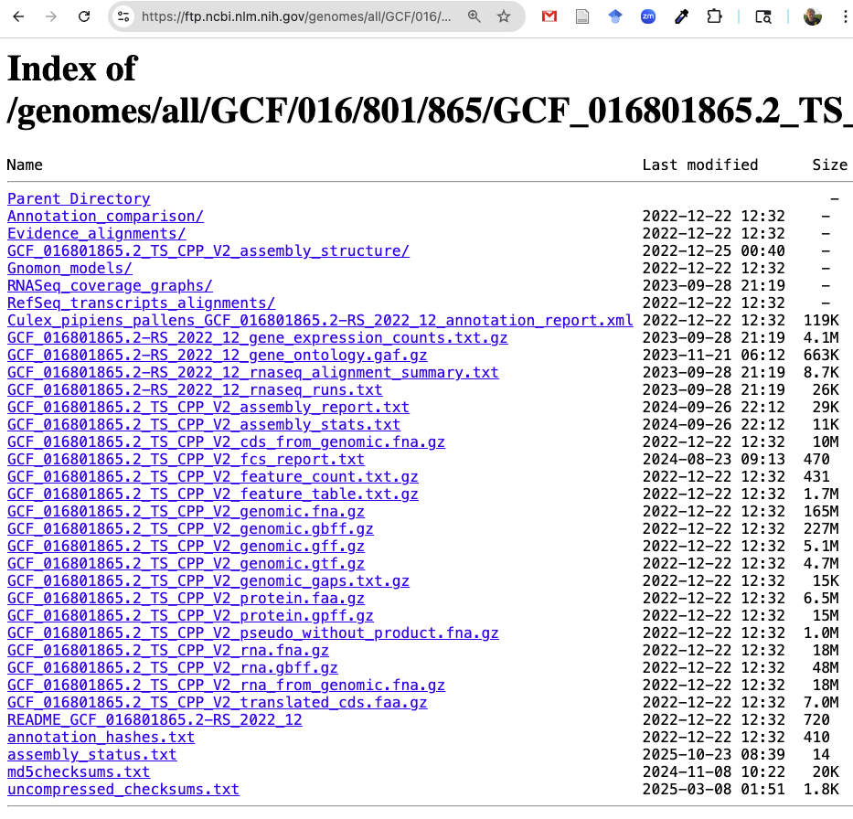

You can right-click on any of the files there and then click “Copy Link Address” (or similar, depending on your browser). That’s how I got the URL to the assembly FASTA (`.fna.gz`) file. Let’s download that file into your `sandbox` dir, so we can practice with it below (in Lecture C, you’ll download it again, into `garrigos/ref`):

```bash
URL=https://ftp.ncbi.nlm.nih.gov/genomes/all/GCF/016/801/865/GCF_016801865.2_TS_CPP_V2/GCF_016801865.2_TS_CPP_V2_genomic.fna.gz
wget -P sandbox "$URL"
```

```
--2026-10-23 10:19:04--  https://ftp.ncbi.nlm.nih.gov/genomes/all/GCF/016/801/865/GCF_016801865.2_TS_CPP_V2/GCF_016801865.2_TS_CPP_V2_genomic.fna.gz
Resolving ftp.ncbi.nlm.nih.gov (ftp.ncbi.nlm.nih.gov)... 130.14.250.13, 130.14.250.10, 130.14.250.7, ...
Connecting to ftp.ncbi.nlm.nih.gov (ftp.ncbi.nlm.nih.gov)|130.14.250.13|:443... connected.
HTTP request sent, awaiting response... 200 OK
Length: 172904433 (165M) [application/x-gzip]
Saving to: ‘sandbox/GCF_016801865.2_TS_CPP_V2_genomic.fna.gz’

GCF_016801865.2_TS_CPP_V2_genomic.fna.gz           100%[===============================================================================================================>] 164.89M  28.5MB/s    in 7.2s

2026-10-23 10:19:12 (23.0 MB/s) - ‘sandbox/GCF_016801865.2_TS_CPP_V2_genomic.fna.gz’ saved [172904433/172904433]
```

- `wget` downloads files to your working dir by default, but we used its `-P` option to directly download into the `sandbox` dir.
- As you can see, `wget` is quite chatty and prints a bunch of logging and progress info to the screen.

Let’s check the downloaded file:

```bash
ls -lh sandbox/GCF*
```

```
-rw-rw----+ 1 jelmer PAS0471 165M Dec 22  2022 sandbox/GCF_016801865.2_TS_CPP_V2_genomic.fna.gz
```

Note that the date shown, `Dec 22 2022`, is when NCBI last modified the file, not when you downloaded it.

In Lecture C, you’ll paste the download command into a `README.md` file, so that anyone (including future you) can see exactly where the file came from, and download it again.

#### Exercise: Download the protein sequences

On the same NCBI page, there is a FASTA file with the sequences of all predicted proteins (`GCF_016801865.2_TS_CPP_V2_protein.faa.gz`).

1. Download it into your `sandbox` dir with a single command.
2. How many proteins are in the file? (Hint: each sequence has a header line starting with `>`, and you don’t need to unzip the file first.)
3. The *Culex pipiens* annotation contains fewer genes than there are proteins in this file. Why might that be?

**NoteAnother download command: `curl`**

Another commonly used download command is `curl`. The two have similar functionality, so you don’t necessarily need to learn both, but you’re likely to see examples with `curl` elsewhere, and genAI tools may suggest it to you. One key difference is that by default, `curl` prints the downloaded contents to the screen instead of saving them to a file: use its `-O` option to save the file under its original name.

**TipMore about downloading genomics data from NCBI**

The optional data management self-study page introduces NCBI’s databases (like GenBank, RefSeq, and the SRA), and shows how to find a reference genome for any species, download genomes with NCBI’s `datasets` tool, and download reads from the SRA.

## 5 File compression

Large data files, like the genome FASTA file you just downloaded, are usually distributed in compressed form to save storage space and download time. In genomics, the most common compression format is **gzip**, recognizable by the `.gz` extension.

Many bioinformatics programs can read gzipped files directly — for example, you’ve never had to decompress your FASTQ files — and to view gzipped files, you’ve been using `zcat` instead of `cat` since week 4. But some programs can’t read gzipped files, so sometimes you do need to decompress (“unzip”) a file. Let’s practice with the genome FASTA file in your `sandbox` dir.

### 5.1 Decompressing files with `gunzip`

To decompress a gzipped file, use the `gunzip` command:

```bash
gunzip sandbox/GCF_016801865.2_TS_CPP_V2_genomic.fna.gz
ls -lh sandbox/GCF*
```

```
-rw-rw----+ 1 jelmer PAS0471 547M Dec 22  2022 sandbox/GCF_016801865.2_TS_CPP_V2_genomic.fna
```

- `gunzip` decompresses files **in place**: the gzipped file is replaced by an uncompressed file with the same name minus the `.gz`.
- You can decompress multiple files at once, e.g. with a wildcard: `gunzip -v data/*.gz` (the `-v` option makes `gunzip` report on each file).

### 5.2 Compressing files with `gzip`

Conversely, to compress a file, use `gzip`, which also works in place:

```bash
gzip sandbox/GCF_016801865.2_TS_CPP_V2_genomic.fna
ls -lh sandbox/GCF*
```

```
-rw-rw----+ 1 jelmer PAS0471 165M Dec 22  2022 sandbox/GCF_016801865.2_TS_CPP_V2_genomic.fna.gz
```

The compressed file is more than 3 times smaller than the uncompressed one. So, only decompress files when needed, and consider compressing large plain-text files that you don’t use often.

**TipWant to keep the original file? *(Click to expand)**

Because `gzip` and `gunzip` replace the input file, you only have one version of the file afterwards. To keep the original, use the `-k` (keep) option:

```bash
gunzip -k sandbox/GCF_016801865.2_TS_CPP_V2_genomic.fna.gz
ls sandbox/GCF*
```

```
sandbox/GCF_016801865.2_TS_CPP_V2_genomic.fna  sandbox/GCF_016801865.2_TS_CPP_V2_genomic.fna.gz
```

You may also see the following method, which additionally lets you choose the name of the output file: the `-c` option makes `gzip`/`gunzip` print the output to standard out, which you can then redirect to a file:

```bash
gzip -c sandbox/GCF_016801865.2_TS_CPP_V2_genomic.fna > sandbox/genome_copy.fna.gz
```

**TipUse the `du` command to see the total size of a dir**

To find out which of your data takes up the most space, you’ll want to know the sizes of dirs. But as you saw in week 4, the sizes that `ls -l` shows for dirs don’t correspond to the total size of the dir and its contents. Instead, use the `du` (**d**isk **u**sage) command – for example:

- Get the **total size for a single dir** with options `-h` (human-readable) and `-s` (summarize, i.e. only show the total):

  ```bash
  du -hs ../garrigos/fastq
  ```

  ```
  941M    ../garrigos/fastq
  ```

- Get the total size of **each dir** directly inside a dir, plus that of the dir itself, with `-d 1` (depth of 1):

  ```bash
  du -h -d 1 ../garrigos
  ```

  ```
  1.0K    ../garrigos/meta
  5.1M    ../garrigos/ref
  941M    ../garrigos/fastq
  946M    ../garrigos/.git
  1.9G    ../garrigos
  ```

## 6 Recap

In this lecture, you have learned about best practices for managing and sharing your data, including why to prefer relative paths and how to organize metadata in spreadsheets (slides), and the following practical applications:

- File transfer to and from OSC with FileZilla (and what other options exist)
- Downloading files at the command line with `wget`
- Compressing and decompressing files with `gzip` and `gunzip`, and checking dir sizes with `du`

The optional data management self-study page covers:

- Sharing data and code across projects, and linking to files and dirs elsewhere with symbolic links (`ln -s`)
- NCBI’s databases, and downloading genomes (`datasets`) and reads from the SRA
- Checking whether downloaded or transferred files are intact with checksums (`md5sum`)
- Viewing and changing file permissions (`ls -l`, `chmod`), e.g. to make your raw data read-only
- More about file compression: compressing program output on the fly, searching gzipped files with `zgrep`, concatenating gzipped files, and packing up entire dirs with `tar`

**NoteThis week’s reading: Reproducibility in plant pathology**

In 2024, the journal *Phytopathology* published a special issue on “Key Challenges in Plant Pathology in the Next Decade”, and reproducibility was one of these challenges (Wang et al. 2024). In that issue, Grünwald et al. (2024) provide guidelines for publishing in the American Phytopathological Society (APS) journals, including on data sharing and code deposition.

## 7 Self-study: Get a DOI for a GitHub repo

In GA5, you’ll get a (test) DOI for your GA5 repo, as discussed in the slides.

To practice beforehand, try it with your `evo` repo from week 5. (This needs to be a public repo: if yours is private, change this in its `Settings` on GitHub, at the bottom of the page.) Real Zenodo DOIs are permanent, so you’ll use the Zenodo Sandbox, a test copy of Zenodo whose DOIs aren’t registered.

1. Go to [Zenodo Sandbox](https://sandbox.zenodo.org/), click “Log in” (not “Create Account”), choose “Sign in with GitHub”, and authorize the Sandbox to access your GitHub account.

[figure not shown]

2. In the Sandbox account dropdown menu (far top right), go to “GitHub”, find your `evo` repo in the list of your repos, and flip the switch next to it.
3. Then, click the repo link, and on the next page, click the green repo button (screenshot on the right): you will be sent to the GitHub page to create a new release for your repo (screenshot below).

[figure not shown]

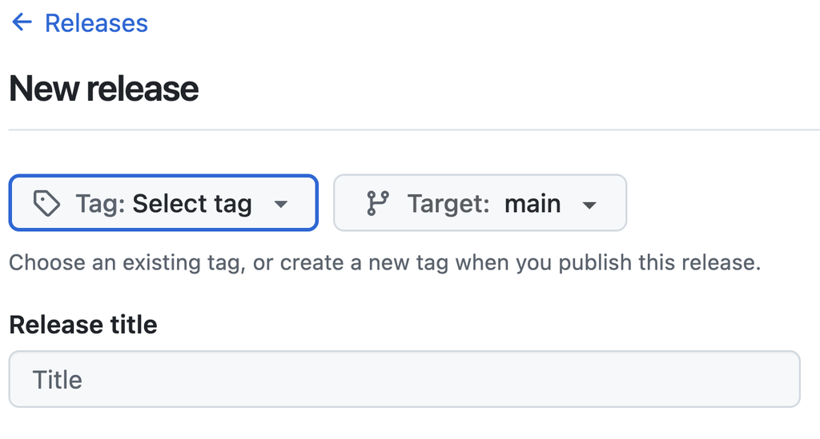

4. You’ll need to create a tag along with the release. Click “**Tag: Select tag**”, then “Create new tag”, type `v1.0` and click “Create” (screenshots below).

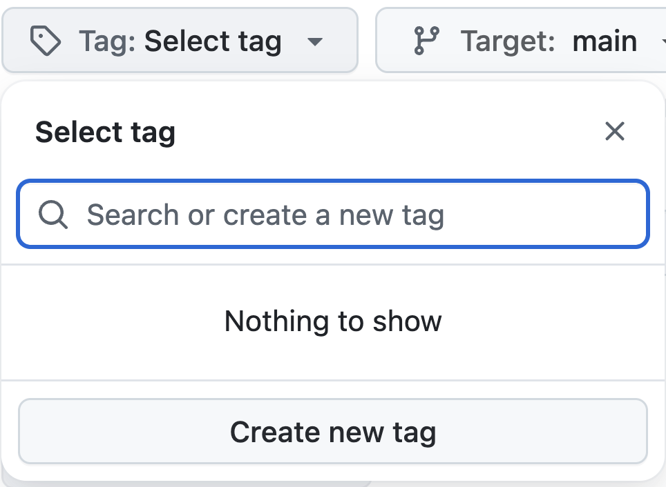

Click “Create new tag”

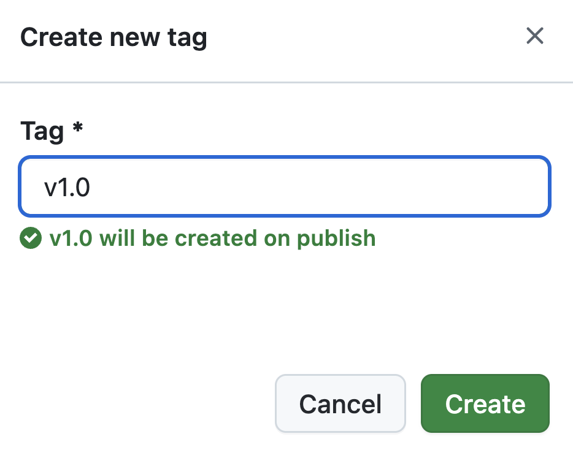

5. You *don’t* have to add a release title or description (though this would be good practice in a real release). Then scroll down and click “**Publish release**” (keep the “Release label” set to the default, “None”).

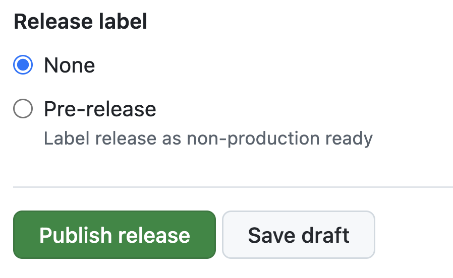

Keep the “Release label” set to the default, “None”, and click “Publish release”

On the right, the GitHub page when the release has been published.

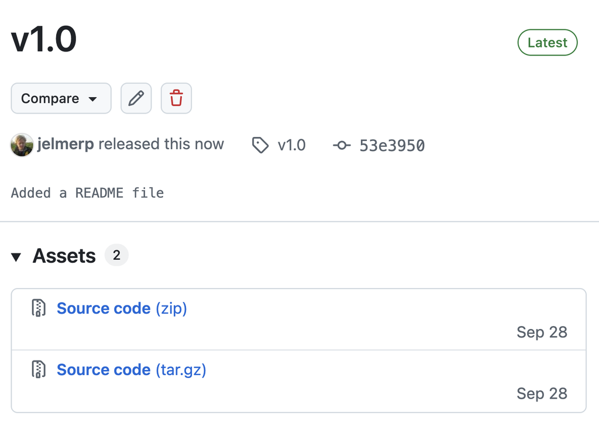

6. Back on the Sandbox GitHub page, refresh after a minute, and you should see that your DOI has been created.

[figure not shown]

7. To add the DOI “badge” to your repo’s README.md file, first click the DOI badge button on the Zenodo Sandbox page (screenshot on the right), and copy the Markdown code snippet that appears (screenshot below).

[figure not shown]

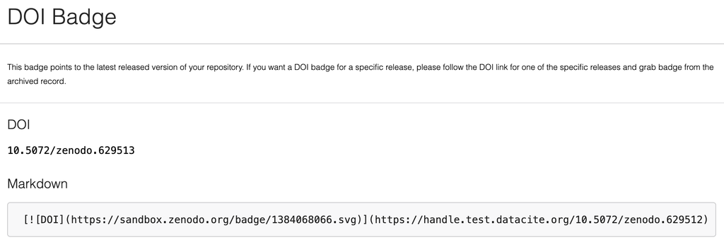

8. Then, edit the `README.md` file in your repo on GitHub, paste the snippet at the top, and commit the change[^3]. You should now see the badge at the top of your README on GitHub:

[figure not shown]

Back to top

## References

Garrigós, Marta, Guillem Ylla, Josué Martínez-de la Puente, Jordi Figuerola, and María José Ruiz-López. 2025. “Two Avian *Plasmodium* Species Trigger Different Transcriptional Responses on Their Vector *Culex pipiens*.” *Molecular Ecology* 34 (15): e17240. https://doi.org/10.1111/mec.17240.

Grünwald, Niklaus J., Clive H. Bock, Jeff H. Chang, et al. 2024. “Open Access and Reproducibility in Plant Pathology Research: Guidelines and Best Practices.” *Phytopathology®* 114 (5): 910–16. https://doi.org/10.1094/PHYTO-12-23-0483-IA.

Wang, Nian, George W. Sundin, Leonardo De La Fuente, et al. 2024. “Key Challenges in Plant Pathology in the Next Decade.” *Phytopathology®* 114 (5): 837–42. https://doi.org/10.1094/PHYTO-04-24-0137-KC.

## Footnotes

[^1]: E.g. because it works on all operating systems and has a more intuitive user interface than Cyberduck, another very commonly used program that works both on Mac and Windows.
[^2]: There is also an icon in the far top-left to access this menu. Additionally, there is a “Quickconnect” bar, but I’ve not managed to connect to OSC with that.
[^3]: Just note that if this was a repo you were actively working on, you would normally do this in VS Code and push the change to GitHub.